# 대대분류 (CN_our) 시계열 데이터 분석

올림푸스

2020-04-28

# 대대분류(CN_our) 시계열 데이터 분석

#### 대대분류(CN_our) 분석을 위한 불필요한 항목제거

```r
train_order_need <- train_order[, -c(3,4,5,6,7,9)]
train_session_need <- train_session[, -c(3,7,8,9)]
train_client <- train_client[]

train_order_tot <- train_order_need %>%
  group_by(CLNT_ID, SESS_ID, CN_our) %>%
  summarise(PD_BUY_CT = sum(PD_BUY_CT),
            PD_BUY_AM = sum(PD_BUY_TOT)
  )


join_table_seor <- left_join(train_order_tot, train_session_need, by=c('CLNT_ID', 'SESS_ID'))


join_table_need <- join_table_seor[, -c(1,2)]

tr_all_need <- join_table_seor[, -c(1,2,3)]


join_no_fashion <- join_table_seor %>%
  subset(CN_our != 'C5')

need_cn <- join_table_need %>%
  group_by(SESS_DT, CN_our) %>%
  summarise(PD_BUY_CT = sum(PD_BUY_CT),
            PD_BUY_AM = sum(PD_BUY_AM),
            TOT_PAG_VIEW_CT = sum(TOT_PAG_VIEW_CT),
            TOT_SESS_HR_V = sum(TOT_SESS_HR_V)
  )


tr_all <- tr_all_need %>%
  group_by(SESS_DT) %>%
  summarise(PD_BUY_CT = sum(PD_BUY_CT),
            PD_BUY_AM = sum(PD_BUY_AM),
            TOT_PAG_VIEW_CT = sum(TOT_PAG_VIEW_CT),
            TOT_SESS_HR_V = sum(TOT_SESS_HR_V)
            ) %>%
  arrange(SESS_DT)

no_fashion <- join_no_fashion %>%
  group_by(SESS_DT, CN_our) %>%
  summarise(PD_BUY_CT = sum(PD_BUY_CT),
            PD_BUY_AM = sum(PD_BUY_AM),
            TOT_PAG_VIEW_CT = sum(TOT_PAG_VIEW_CT),
            TOT_SESS_HR_V = sum(TOT_SESS_HR_V)
  )


need_cn$SESS_DT <- as.Date(need_cn$SESS_DT)
need_cn$DT_CHR <- as.character(need_cn$SESS_DT, format = '%m-%d')

tr_all$SESS_DT <- as.Date(tr_all$SESS_DT)
tr_all$DT_CHR <- as.character(tr_all$SESS_DT, format = '%m-%d')

no_fashion$SESS_DT <- as.Date(no_fashion$SESS_DT)
no_fashion$DT_CHR <- as.character(no_fashion$SESS_DT, format = '%m-%d')


C1 <- need_cn %>%
  filter(CN_our %in% c('C1'))
C2 <- need_cn %>%
  filter(CN_our %in% c('C2'))
C3 <- need_cn %>%
  filter(CN_our %in% c('C3'))
C4 <- need_cn %>%
  filter(CN_our %in% c('C4'))
C5 <- need_cn %>%
  filter(CN_our %in% c('C5'))
C6 <- need_cn %>%
  filter(CN_our %in% c('C6'))
C7 <- need_cn %>%
  filter(CN_our %in% c('C7'))
C8 <- need_cn %>%
  filter(CN_our %in% c('C8'))
C9 <- need_cn %>%
  filter(CN_our %in% c('C9'))
C10 <- need_cn %>%
  filter(CN_our %in% c('C10'))



#C1시각화----
C1_AM <- ggplot(C1, aes(x = SESS_DT, y = PD_BUY_AM )) +
  geom_line() + labs(x = '일자',  y = '구매액', title = "전자제품 구매액") +
  annotate("text", x = C1$SESS_DT, y = C1$PD_BUY_AM, label = C1$DT_CHR) +
  scale_x_date(limits = c(min(C1$SESS_DT), max(C1$SESS_DT)),
               date_breaks = 'month',
               labels = date_format('%m-%d')) +
  scale_color_economist() + theme_economist() +
  theme(axis.text.x = element_text(angle =25), legend.position = 'none')
C1_CT <- ggplot(C1, aes(x = SESS_DT, y = PD_BUY_CT )) +
  geom_line() + labs(x = '일자',  y = '구매 수량', title = "전자제품 구매 수량") +
  annotate("text", x = C1$SESS_DT, y = C1$PD_BUY_CT, label = C1$DT_CHR) +
  scale_x_date(limits = c(min(C1$SESS_DT), max(C1$SESS_DT)),
               date_breaks = 'month',
               labels = date_format('%m-%d')) +
  scale_color_economist() + theme_economist() +
  theme(axis.text.x = element_text(angle =25), legend.position = 'none')
C1_PAG <- ggplot(C1, aes(x = SESS_DT, y = TOT_PAG_VIEW_CT )) +
  geom_line() + labs(x = '일자',  y = '페이지 뷰 수', title = "전자제품 페이지 뷰 수") +
  annotate("text", x = C1$SESS_DT, y = C1$TOT_PAG_VIEW_CT, label = C1$DT_CHR) +
  scale_x_date(limits = c(min(C1$SESS_DT), max(C1$SESS_DT)),
               date_breaks = 'month',
               labels = date_format('%m-%d')) +
  scale_color_economist() + theme_economist() +
  theme(axis.text.x = element_text(angle =25), legend.position = 'none')
C1_HR <- ggplot(C1, aes(x = SESS_DT, y = TOT_SESS_HR_V )) +
  geom_line() + labs(x = '일자',  y = '세션 머문 시간', title = "전자제품 세션 머문 시간") +
  annotate("text", x = C1$SESS_DT, y = C1$TOT_SESS_HR_V, label = C1$DT_CHR) +
  scale_x_date(limits = c(min(C1$SESS_DT), max(C1$SESS_DT)),
               date_breaks = 'month',
               labels = date_format('%m-%d')) +
  scale_color_economist() + theme_economist() +
  theme(axis.text.x = element_text(angle =25), legend.position = 'none')
```

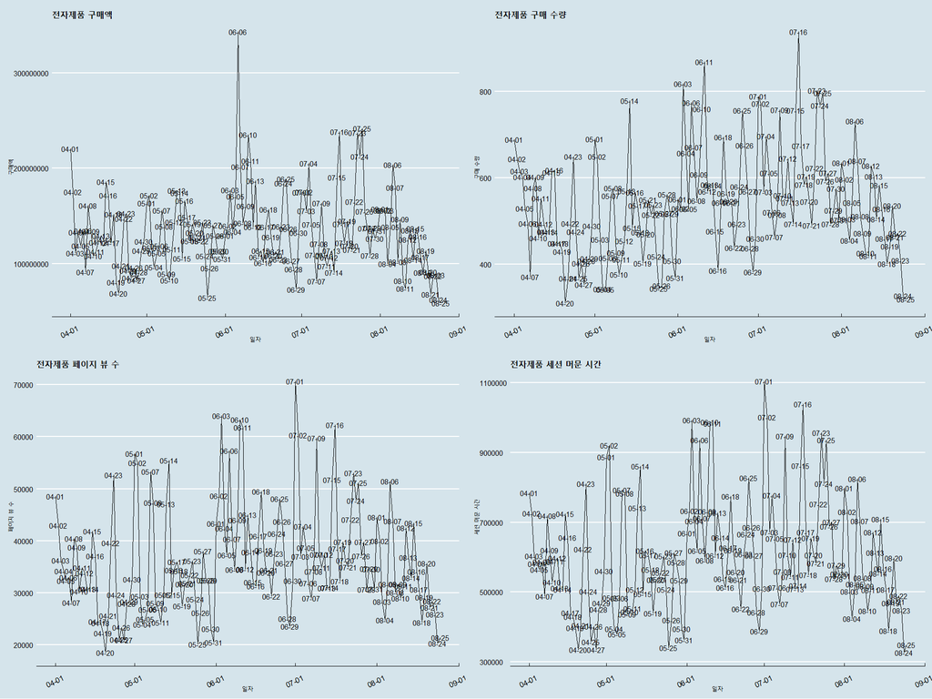

```r
ggarrange(C1_AM, C1_CT, C1_PAG, C1_HR)
```

#### Insight : 전자제품은 구매데이터와 온라인 행동데이터의 차이가 보인다

#### 이는 온라인 홈페이지 상품 구매를 위한 구성이 부족함이 있을 수 있음

```r
#C2시각화----
C2_AM <- ggplot(C2, aes(x = SESS_DT, y = PD_BUY_AM )) +
  geom_line() + labs(x = '일자',  y = '구매액', title = "리빙 구매액") +
  annotate("text", x = C2$SESS_DT, y = C2$PD_BUY_AM, label = C2$DT_CHR) +
  scale_x_date(limits = c(min(C1$SESS_DT), max(C1$SESS_DT)),
               date_breaks = 'month',
               labels = date_format('%m-%d')) +
  scale_color_economist() + theme_economist() +
  theme(axis.text.x = element_text(angle =25), legend.position = 'none')

C2_CT <- ggplot(C2, aes(x = SESS_DT, y = PD_BUY_CT )) +
  geom_line() + labs(x = '일자',  y = '구매 수량', title = "리빙 구매 수량") +
  annotate("text", x = C2$SESS_DT, y = C2$PD_BUY_CT, label = C2$DT_CHR) +
  scale_x_date(limits = c(min(C2$SESS_DT), max(C2$SESS_DT)),
               date_breaks = 'month',
               labels = date_format('%m-%d')) +
  scale_color_economist() + theme_economist() +
  theme(axis.text.x = element_text(angle =25), legend.position = 'none')
C2_PAG <- ggplot(C2, aes(x = SESS_DT, y = TOT_PAG_VIEW_CT )) +
  geom_line() + labs(x = '일자',  y = '페이지 뷰 수', title = "리빙 페이지 뷰 수") +
  annotate("text", x = C2$SESS_DT, y = C2$TOT_PAG_VIEW_CT, label = C2$DT_CHR) +
  scale_x_date(limits = c(min(C2$SESS_DT), max(C2$SESS_DT)),
               date_breaks = 'month',
               labels = date_format('%m-%d')) +
  scale_color_economist() + theme_economist() +
  theme(axis.text.x = element_text(angle =25), legend.position = 'none')
C2_HR <- ggplot(C2, aes(x = SESS_DT, y = TOT_SESS_HR_V )) +
  geom_line() + labs(x = '일자',  y = '세션 머문 시간', title = "리빙 세션 머문 시간") +
  annotate("text", x = C2$SESS_DT, y = C2$TOT_SESS_HR_V, label = C2$DT_CHR) +
  scale_x_date(limits = c(min(C2$SESS_DT), max(C2$SESS_DT)),
               date_breaks = 'month',
               labels = date_format('%m-%d')) +
  scale_color_economist() + theme_economist() +
  theme(axis.text.x = element_text(angle =25), legend.position = 'none')
```

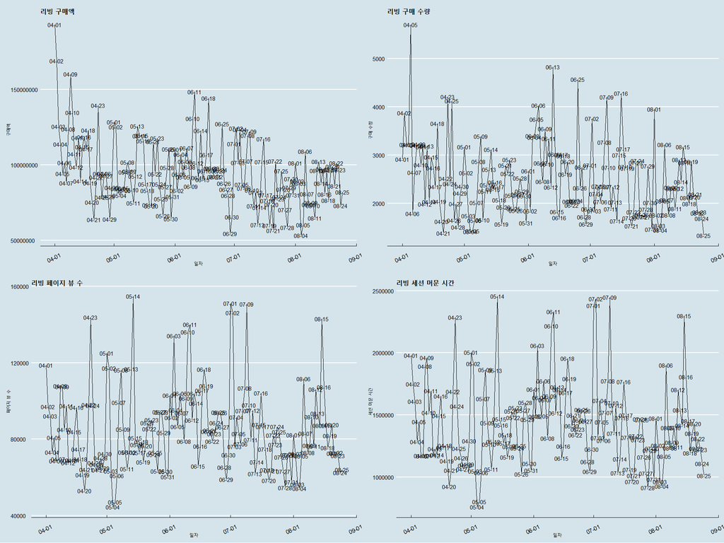

```r
ggarrange(C2_AM, C2_CT, C2_PAG, C2_HR)
```

#### Insight : 특히 4월 중순 ~ 5월 중순의 온라인 행동 데이터와 구매데이터가 극심히 차이가 #### 나고 있음을 볼 수 있고 이 또한 온라인 홈페이지 구성이 부족하였을 수 있음

```r
#C3시각화----
C3_AM <- ggplot(C3, aes(x = SESS_DT, y = PD_BUY_AM )) +
  geom_line() + labs(x = '일자',  y = '구매액', title = "식품 구매액") +
  annotate("text", x = C3$SESS_DT, y = C3$PD_BUY_AM, label = C3$DT_CHR) +
  scale_x_date(limits = c(min(C3$SESS_DT), max(C3$SESS_DT)),
               date_breaks = 'month',
               labels = date_format('%m-%d')) +
  scale_color_economist() + theme_economist() +
  theme(axis.text.x = element_text(angle =25), legend.position = 'none')
C3_CT <- ggplot(C3, aes(x = SESS_DT, y = PD_BUY_CT )) +
  geom_line() + labs(x = '일자',  y = '구매 수량', title = "식품 구매 수량") +
  annotate("text", x = C3$SESS_DT, y = C3$PD_BUY_CT, label = C3$DT_CHR) +
  scale_x_date(limits = c(min(C3$SESS_DT), max(C3$SESS_DT)),
               date_breaks = 'month',
               labels = date_format('%m-%d')) +
  scale_color_economist() + theme_economist() +
  theme(axis.text.x = element_text(angle =25), legend.position = 'none')
C3_PAG <- ggplot(C3, aes(x = SESS_DT, y = TOT_PAG_VIEW_CT )) +
  geom_line() + labs(x = '일자',  y = '페이지 뷰 수', title = "식품 페이지 뷰 수") +
  annotate("text", x = C3$SESS_DT, y = C3$TOT_PAG_VIEW_CT, label = C3$DT_CHR) +
  scale_x_date(limits = c(min(C3$SESS_DT), max(C3$SESS_DT)),
               date_breaks = 'month',
               labels = date_format('%m-%d')) +
  scale_color_economist() + theme_economist() +
  theme(axis.text.x = element_text(angle =25), legend.position = 'none')
C3_HR <- ggplot(C3, aes(x = SESS_DT, y = TOT_SESS_HR_V )) +
  geom_line() + labs(x = '일자',  y = '세션 머문 시간', title = "식품 세션 머문 시간") +
  annotate("text", x = C3$SESS_DT, y = C3$TOT_SESS_HR_V, label = C3$DT_CHR) +
  scale_x_date(limits = c(min(C3$SESS_DT), max(C3$SESS_DT)),
               date_breaks = 'month',
               labels = date_format('%m-%d')) +
  scale_color_economist() + theme_economist() +
  theme(axis.text.x = element_text(angle =25), legend.position = 'none')
```

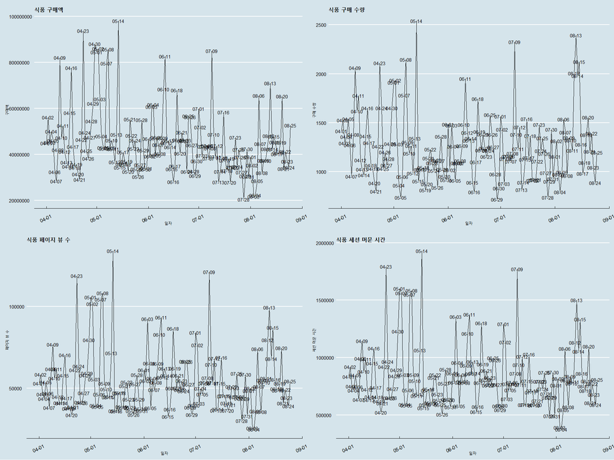

```r
ggarrange(C3_AM, C3_CT, C3_PAG, C3_HR)
```

#### Insight : 식품은 특정 시기의 반짝 구매하는 특성이 강한 계절성을 띄는 것을 볼 수 있음

```r
#C4시각화----
C4_AM <- ggplot(C4, aes(x = SESS_DT, y = PD_BUY_AM )) +
  geom_line() + labs(x = '일자',  y = '구매액', title = "스포츠 용품 구매액") +
  annotate("text", x = C4$SESS_DT, y = C4$PD_BUY_AM, label = C4$DT_CHR) +
  scale_x_date(limits = c(min(C4$SESS_DT), max(C4$SESS_DT)),
               date_breaks = 'month',
               labels = date_format('%m-%d')) +
  scale_color_economist() + theme_economist() +
  theme(axis.text.x = element_text(angle =25), legend.position = 'none')
C4_CT <- ggplot(C4, aes(x = SESS_DT, y = PD_BUY_CT )) +
  geom_line() + labs(x = '일자',  y = '구매 수량', title = "스포츠 용품 구매 수량") +
  annotate("text", x = C4$SESS_DT, y = C4$PD_BUY_CT, label = C4$DT_CHR) +
  scale_x_date(limits = c(min(C4$SESS_DT), max(C4$SESS_DT)),
               date_breaks = 'month',
               labels = date_format('%m-%d')) +
  scale_color_economist() + theme_economist() +
  theme(axis.text.x = element_text(angle =25), legend.position = 'none')
C4_PAG <- ggplot(C4, aes(x = SESS_DT, y = TOT_PAG_VIEW_CT )) +
  geom_line() + labs(x = '일자',  y = '페이지 뷰 수', title = "스포츠 용품 페이지 뷰 수") +
  annotate("text", x = C4$SESS_DT, y = C4$TOT_PAG_VIEW_CT, label = C4$DT_CHR) +
  scale_x_date(limits = c(min(C4$SESS_DT), max(C4$SESS_DT)),
               date_breaks = 'month',
               labels = date_format('%m-%d')) +
  scale_color_economist() + theme_economist() +
  theme(axis.text.x = element_text(angle =25), legend.position = 'none')
C4_HR <- ggplot(C4, aes(x = SESS_DT, y = TOT_SESS_HR_V )) +
  geom_line() + labs(x = '일자',  y = '세션 머문 시간', title = "스포츠 용품 세션 머문 시간") +
  annotate("text", x = C4$SESS_DT, y = C4$TOT_SESS_HR_V, label = C4$DT_CHR) +
  scale_x_date(limits = c(min(C4$SESS_DT), max(C4$SESS_DT)),
               date_breaks = 'month',
               labels = date_format('%m-%d')) +
  scale_color_economist() + theme_economist() +
  theme(axis.text.x = element_text(angle =25), legend.position = 'none')
```

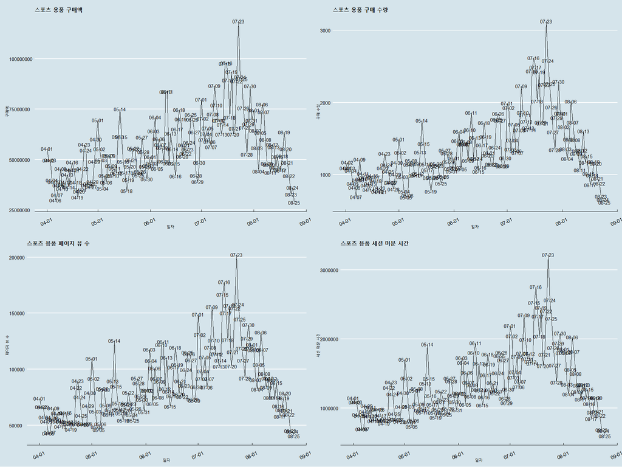

```r
ggarrange(C4_AM, C4_CT, C4_PAG, C4_HR)
```

#### Insight : 스포츠 용품의 경우 온라인 행동데이터와 구매데이터가 같은 추세를 보여 홈페이지 구성이 잘되어진 것으로 보이고 스포츠 용품의 경우 여름시즌인 7-8월에 구매가 많다

#### 스포츠용품의 상품 구성이 너무 여름용 스포츠 용품에 치우쳐져있는 상품 구성이 아닐까 하는 추측

```r
#C5시각화----
C5_AM <- ggplot(C5, aes(x = SESS_DT, y = PD_BUY_AM )) +
  geom_line() + labs(x = '일자',  y = '구매액', title = "패션 구매액") +
  annotate("text", x = C5$SESS_DT, y = C5$PD_BUY_AM, label = C5$DT_CHR) +
  scale_x_date(limits = c(min(C5$SESS_DT), max(C5$SESS_DT)),
               date_breaks = 'month',
               labels = date_format('%m-%d')) +
  scale_color_economist() + theme_economist() +
  theme(axis.text.x = element_text(angle =25), legend.position = 'none')
C5_CT <- ggplot(C5, aes(x = SESS_DT, y = PD_BUY_CT )) +
  geom_line() + labs(x = '일자',  y = '구매 수량', title = "패션 구매 수량") +
  annotate("text", x = C5$SESS_DT, y = C5$PD_BUY_CT, label = C5$DT_CHR) +
  scale_x_date(limits = c(min(C5$SESS_DT), max(C5$SESS_DT)),
               date_breaks = 'month',
               labels = date_format('%m-%d')) +
  scale_color_economist() + theme_economist() +
  theme(axis.text.x = element_text(angle =25), legend.position = 'none')
C5_PAG <- ggplot(C5, aes(x = SESS_DT, y = TOT_PAG_VIEW_CT )) +
  geom_line() + labs(x = '일자',  y = '페이지 뷰 수', title = "패션 페이지 뷰 수") +
  annotate("text", x = C5$SESS_DT, y = C5$TOT_PAG_VIEW_CT, label = C5$DT_CHR) +
  scale_x_date(limits = c(min(C5$SESS_DT), max(C5$SESS_DT)),
               date_breaks = 'month',
               labels = date_format('%m-%d')) +
  scale_color_economist() + theme_economist() +
  theme(axis.text.x = element_text(angle =25), legend.position = 'none')
C5_HR <- ggplot(C5, aes(x = SESS_DT, y = TOT_SESS_HR_V )) +
  geom_line() + labs(x = '일자',  y = '세션 머문 시간', title = "패션 세션 머문 시간") +
  annotate("text", x = C5$SESS_DT, y = C5$TOT_SESS_HR_V, label = C5$DT_CHR) +
  scale_x_date(limits = c(min(C5$SESS_DT), max(C5$SESS_DT)),
               date_breaks = 'month',
               labels = date_format('%m-%d')) +
  scale_color_economist() + theme_economist() +
  theme(axis.text.x = element_text(angle =25), legend.position = 'none')
```

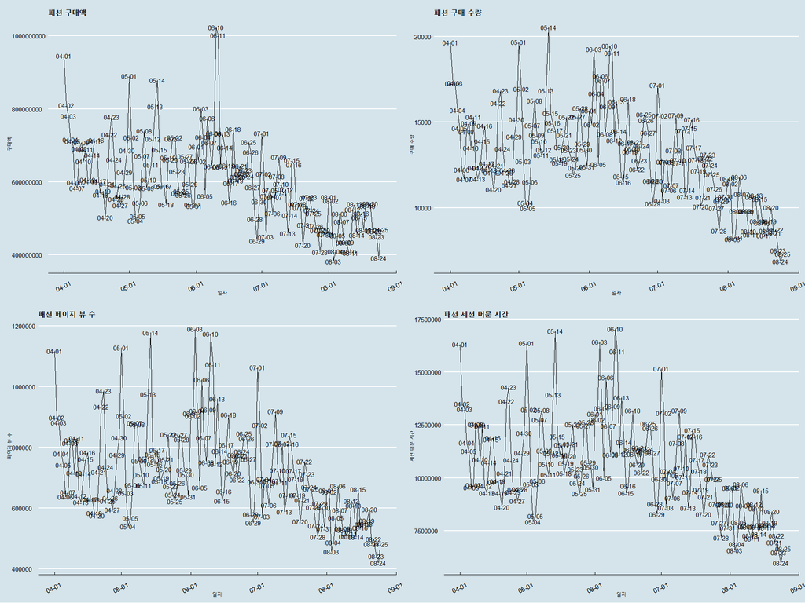

```r
ggarrange(C5_AM, C5_CT, C5_PAG, C5_HR)
```

#### Insight : 패션은 위의 스포츠 용품과 같이 행동과 구매데이터가 일치하는 추세를 보임

#### 7월 초 ~ 9월 사이의 상품구성이 미미하여 대체 가능한 마케팅이 6월 말 부터 이루어졌어야 하지 않나 생각해봄

```r
#C6시각화----
C6_AM <- ggplot(C6, aes(x = SESS_DT, y = PD_BUY_AM )) +
  geom_line() + labs(x = '일자',  y = '구매액', title = "뷰티 구매액") +
  annotate("text", x = C6$SESS_DT, y = C6$PD_BUY_AM, label = C6$DT_CHR) +
  scale_x_date(limits = c(min(C6$SESS_DT), max(C6$SESS_DT)),
               date_breaks = 'month',
               labels = date_format('%m-%d')) +
  scale_color_economist() + theme_economist() +
  theme(axis.text.x = element_text(angle =25), legend.position = 'none')
C6_CT <- ggplot(C6, aes(x = SESS_DT, y = PD_BUY_CT )) +
  geom_line() + labs(x = '일자',  y = '구매 수량', title = "뷰티 구매 수량") +
  annotate("text", x = C6$SESS_DT, y = C6$PD_BUY_CT, label = C6$DT_CHR) +
  scale_x_date(limits = c(min(C6$SESS_DT), max(C6$SESS_DT)),
               date_breaks = 'month',
               labels = date_format('%m-%d')) +
  scale_color_economist() + theme_economist() +
  theme(axis.text.x = element_text(angle =25), legend.position = 'none')
C6_PAG <- ggplot(C6, aes(x = SESS_DT, y = TOT_PAG_VIEW_CT )) +
  geom_line() + labs(x = '일자',  y = '페이지 뷰 수', title = "뷰티 페이지 뷰 수") +
  annotate("text", x = C6$SESS_DT, y = C6$TOT_PAG_VIEW_CT, label = C6$DT_CHR) +
  scale_x_date(limits = c(min(C6$SESS_DT), max(C6$SESS_DT)),
               date_breaks = 'month',
               labels = date_format('%m-%d')) +
  scale_color_economist() + theme_economist() +
  theme(axis.text.x = element_text(angle =25), legend.position = 'none')
C6_HR <- ggplot(C6, aes(x = SESS_DT, y = TOT_SESS_HR_V )) +
  geom_line() + labs(x = '일자',  y = '세션 머문 시간', title = "뷰티 세션 머문 시간") +
  annotate("text", x = C6$SESS_DT, y = C6$TOT_SESS_HR_V, label = C6$DT_CHR) +
  scale_x_date(limits = c(min(C6$SESS_DT), max(C6$SESS_DT)),
               date_breaks = 'month',
               labels = date_format('%m-%d')) +
  scale_color_economist() + theme_economist() +
  theme(axis.text.x = element_text(angle =25), legend.position = 'none')
```

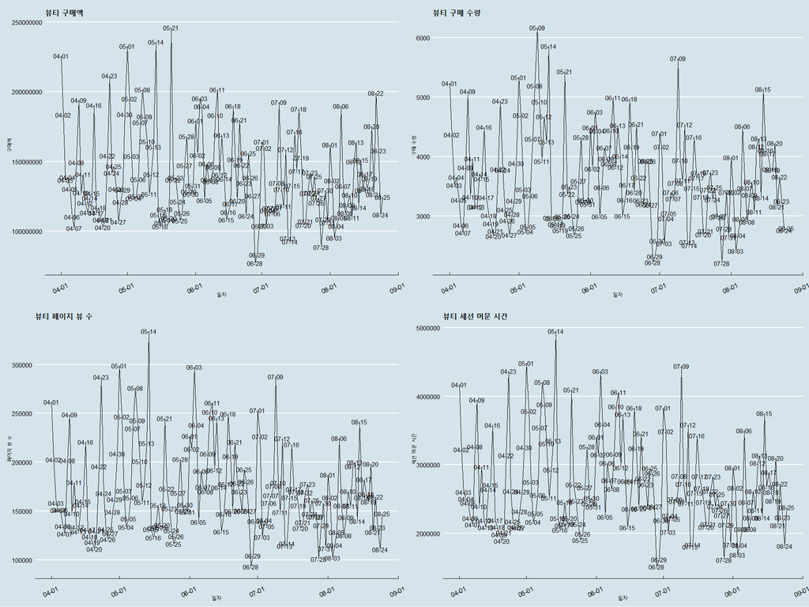

```r
ggarrange(C6_AM, C6_CT, C6_PAG, C6_HR)
```

#### Insight : 뷰티용품은 대체로 하향 상향 추세가 보이지않는 일정한 그래프를 보임

#### 뷰티 용품의 경우 살 때 한 두개 묶음 상품이 많거나한번 사고나면 다음 한주까지의 구매 및 행동데이터의 수치가 급히 주는 모습을 보임

```r
#C7시각화----
C7_AM <- ggplot(C7, aes(x = SESS_DT, y = PD_BUY_AM )) +
  geom_line() + labs(x = '일자',  y = '구매액', title = "유아용품 구매액") +
  annotate("text", x = C7$SESS_DT, y = C7$PD_BUY_AM, label = C7$DT_CHR) +
  scale_x_date(limits = c(min(C7$SESS_DT), max(C7$SESS_DT)),
               date_breaks = 'month',
               labels = date_format('%m-%d')) +
  scale_color_economist() + theme_economist() +
  theme(axis.text.x = element_text(angle =25), legend.position = 'none')
C7_CT <- ggplot(C7, aes(x = SESS_DT, y = PD_BUY_CT )) +
  geom_line() + labs(x = '일자',  y = '구매 수량', title = "유아용품 구매 수량") +
  annotate("text", x = C7$SESS_DT, y = C7$PD_BUY_CT, label = C7$DT_CHR) +
  scale_x_date(limits = c(min(C7$SESS_DT), max(C7$SESS_DT)),
               date_breaks = 'month',
               labels = date_format('%m-%d')) +
  scale_color_economist() + theme_economist() +
  theme(axis.text.x = element_text(angle =25), legend.position = 'none')
C7_PAG <- ggplot(C7, aes(x = SESS_DT, y = TOT_PAG_VIEW_CT )) +
  geom_line() + labs(x = '일자',  y = '페이지 뷰 수', title = "유아용품 페이지 뷰 수") +
  annotate("text", x = C7$SESS_DT, y = C7$TOT_PAG_VIEW_CT, label = C7$DT_CHR) +
  scale_x_date(limits = c(min(C7$SESS_DT), max(C7$SESS_DT)),
               date_breaks = 'month',
               labels = date_format('%m-%d')) +
  scale_color_economist() + theme_economist() +
  theme(axis.text.x = element_text(angle =25), legend.position = 'none')
C7_HR <- ggplot(C7, aes(x = SESS_DT, y = TOT_SESS_HR_V )) +
  geom_line() + labs(x = '일자',  y = '세션 머문 시간', title = "유아용품 세션 머문 시간") +
  annotate("text", x = C7$SESS_DT, y = C7$TOT_SESS_HR_V, label = C7$DT_CHR) +
  scale_x_date(limits = c(min(C7$SESS_DT), max(C7$SESS_DT)),
               date_breaks = 'month',
               labels = date_format('%m-%d')) +
  scale_color_economist() + theme_economist() +
  theme(axis.text.x = element_text(angle =25), legend.position = 'none')
```

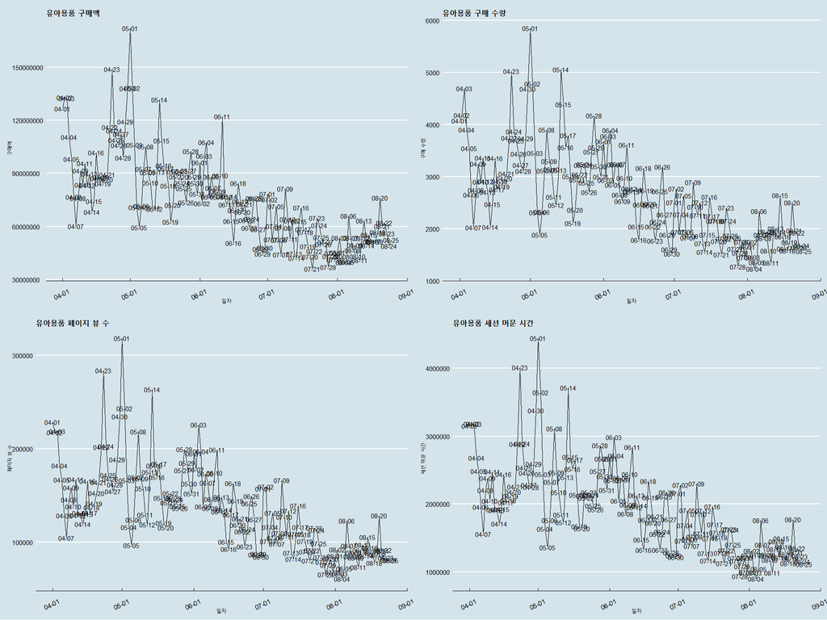

```r
ggarrange(C7_AM, C7_CT, C7_PAG, C7_HR)
```

#### Insight : 유아용품도 위의 스포츠, 패션 등과 같은 용품들처럼 두 데이터 간의 같은 추세를 보이며 5월 초 부터는 급격히 하락하지 않기 위한 마케팅 전략의 필요성이 필요해보임

```r
#C8시각화----
C8_AM <- ggplot(C8, aes(x = SESS_DT, y = PD_BUY_AM )) +
  geom_line() + labs(x = '일자',  y = '구매액', title = "취미용품 구매액") +
  annotate("text", x = C8$SESS_DT, y = C8$PD_BUY_AM, label = C8$DT_CHR) +
  scale_x_date(limits = c(min(C8$SESS_DT), max(C8$SESS_DT)),
               date_breaks = 'month',
               labels = date_format('%m-%d')) +
  scale_color_economist() + theme_economist() +
  theme(axis.text.x = element_text(angle =25), legend.position = 'none')
C8_CT <- ggplot(C8, aes(x = SESS_DT, y = PD_BUY_CT )) +
  geom_line() + labs(x = '일자',  y = '구매 수량', title = "취미용품 구매 수량") +
  annotate("text", x = C8$SESS_DT, y = C8$PD_BUY_CT, label = C8$DT_CHR) +
  scale_x_date(limits = c(min(C8$SESS_DT), max(C8$SESS_DT)),
               date_breaks = 'month',
               labels = date_format('%m-%d')) +
  scale_color_economist() + theme_economist() +
  theme(axis.text.x = element_text(angle =25), legend.position = 'none')
C8_PAG <- ggplot(C8, aes(x = SESS_DT, y = TOT_PAG_VIEW_CT )) +
  geom_line() + labs(x = '일자',  y = '페이지 뷰 수', title = "취미용품 페이지 뷰 수") +
  annotate("text", x = C8$SESS_DT, y = C8$TOT_PAG_VIEW_CT, label = C8$DT_CHR) +
  scale_x_date(limits = c(min(C8$SESS_DT), max(C8$SESS_DT)),
               date_breaks = 'month',
               labels = date_format('%m-%d')) +
  scale_color_economist() + theme_economist() +
  theme(axis.text.x = element_text(angle =25), legend.position = 'none')
C8_HR <- ggplot(C8, aes(x = SESS_DT, y = TOT_SESS_HR_V )) +
  geom_line() + labs(x = '일자',  y = '세션 머문 시간', title = "취미용품 세션 머문 시간") +
  annotate("text", x = C8$SESS_DT, y = C8$TOT_SESS_HR_V, label = C8$DT_CHR) +
  scale_x_date(limits = c(min(C8$SESS_DT), max(C8$SESS_DT)),
               date_breaks = 'month',
               labels = date_format('%m-%d')) +
  scale_color_economist() + theme_economist() +
  theme(axis.text.x = element_text(angle =25), legend.position = 'none')
```

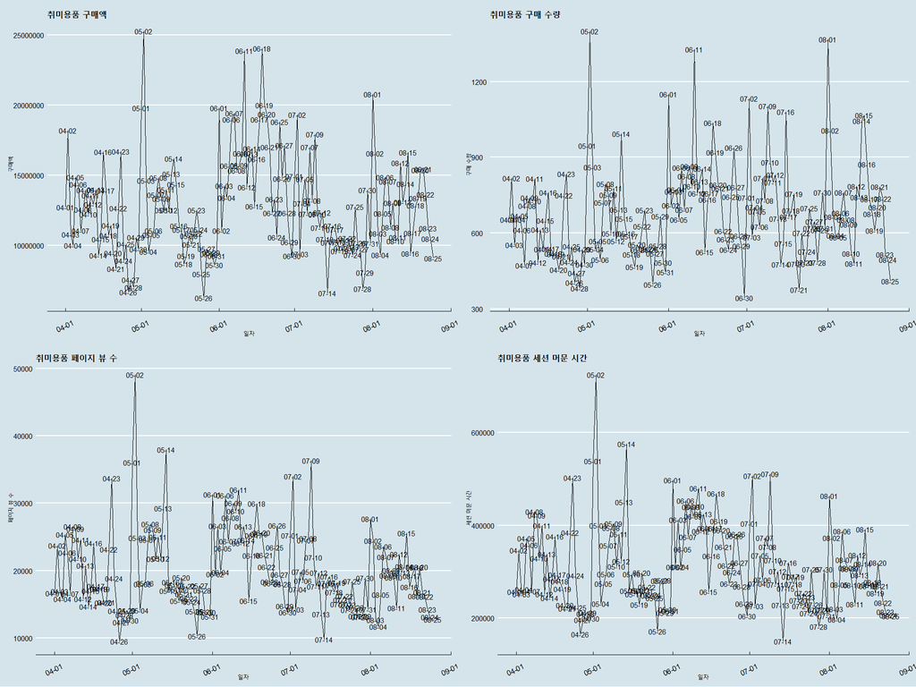

```r
ggarrange(C8_AM, C8_CT, C8_PAG, C8_HR)
```

#### Insight : 취미용품의 경우 5월 초 6월 중순 8월 초에 가장 높은 구매액을 보이고 있고 구매액이 높은 구간의 팔린 상품들의 내역들을 확인할 필요가 있어보임

```r
#C9시각화----
C9_AM <- ggplot(C9, aes(x = SESS_DT, y = PD_BUY_AM )) +
  geom_line() + labs(x = '일자',  y = '구매액', title = "사무용품 구매액") +
  annotate("text", x = C9$SESS_DT, y = C9$PD_BUY_AM, label = C9$DT_CHR) +
  scale_x_date(limits = c(min(C9$SESS_DT), max(C9$SESS_DT)),
               date_breaks = 'month',
               labels = date_format('%m-%d')) +
  scale_color_economist() + theme_economist() +
  theme(axis.text.x = element_text(angle =25), legend.position = 'none')
C9_CT <- ggplot(C9, aes(x = SESS_DT, y = PD_BUY_CT )) +
  geom_line() + labs(x = '일자',  y = '구매 수량', title = "사무용품 구매 수량") +
  annotate("text", x = C9$SESS_DT, y = C9$PD_BUY_CT, label = C9$DT_CHR) +
  scale_x_date(limits = c(min(C9$SESS_DT), max(C9$SESS_DT)),
               date_breaks = 'month',
               labels = date_format('%m-%d')) +
  scale_color_economist() + theme_economist() +
  theme(axis.text.x = element_text(angle =25), legend.position = 'none')
C9_PAG <- ggplot(C9, aes(x = SESS_DT, y = TOT_PAG_VIEW_CT )) +
  geom_line() + labs(x = '일자',  y = '페이지 뷰 수', title = "사무용품 페이지 뷰 수") +
  annotate("text", x = C9$SESS_DT, y = C9$TOT_PAG_VIEW_CT, label = C9$DT_CHR) +
  scale_x_date(limits = c(min(C9$SESS_DT), max(C9$SESS_DT)),
               date_breaks = 'month',
               labels = date_format('%m-%d')) +
  scale_color_economist() + theme_economist() +
  theme(axis.text.x = element_text(angle =25), legend.position = 'none')
C9_HR <- ggplot(C9, aes(x = SESS_DT, y = TOT_SESS_HR_V )) +
  geom_line() + labs(x = '일자',  y = '세션 머문 시간', title = "사무용품 세션 머문 시간") +
  annotate("text", x = C9$SESS_DT, y = C9$TOT_SESS_HR_V, label = C9$DT_CHR) +
  scale_x_date(limits = c(min(C9$SESS_DT), max(C9$SESS_DT)),
               date_breaks = 'month',
               labels = date_format('%m-%d')) +
  scale_color_economist() + theme_economist() +
  theme(axis.text.x = element_text(angle =25), legend.position = 'none')
```

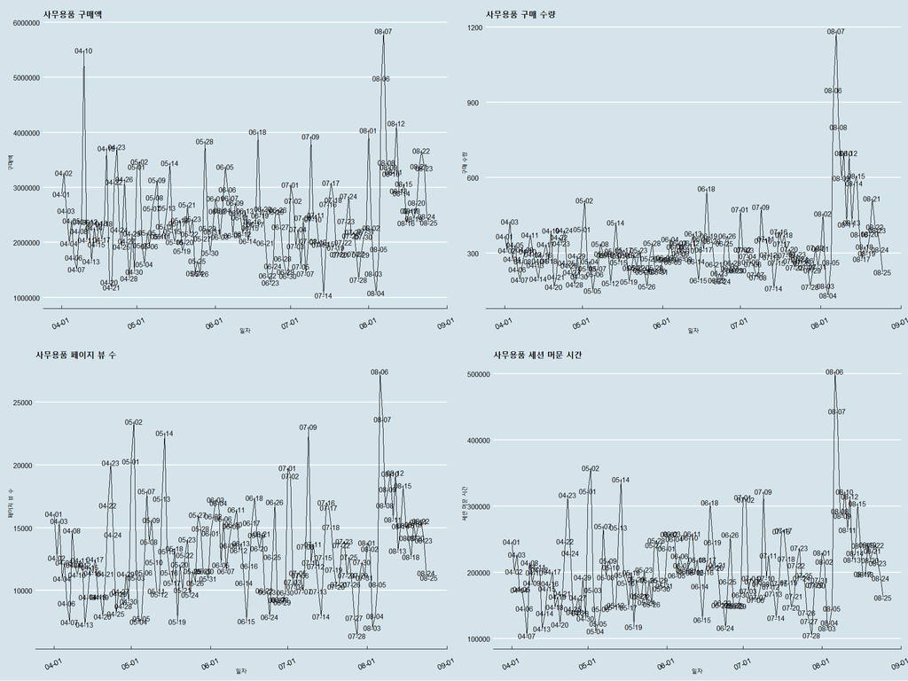

```r
ggarrange(C9_AM, C9_CT, C9_PAG, C9_HR)
```

```r
#C10시각화----
C10_AM <- ggplot(C10, aes(x = SESS_DT, y = PD_BUY_AM)) +
  geom_line() + labs(x = '일자',  y = '구매액', title = "상품권 구매액") +
  annotate("text", x = C10$SESS_DT, y = C10$PD_BUY_AM, label = C10$DT_CHR) +
  scale_x_date(limits = c(min(C10$SESS_DT), max(C10$SESS_DT)),
               date_breaks = 'month',
               labels = date_format('%m-%d')) +
  scale_color_economist() + theme_economist() +
  theme(axis.text.x = element_text(angle =25), legend.position = 'none')
C10_CT <- ggplot(C10, aes(x = SESS_DT, y = PD_BUY_CT )) +
  geom_line() + labs(x = '일자',  y = '구매 수량', title = "상품권 구매 수량") +
  annotate("text", x = C10$SESS_DT, y = C10$PD_BUY_CT, label = C10$DT_CHR) +
  scale_x_date(limits = c(min(C10$SESS_DT), max(C10$SESS_DT)),
               date_breaks = 'month',
               labels = date_format('%m-%d')) +
  scale_color_economist() + theme_economist() +
  theme(axis.text.x = element_text(angle =25), legend.position = 'none')
C10_PAG <- ggplot(C10, aes(x = SESS_DT, y = TOT_PAG_VIEW_CT )) +
  geom_line() + labs(x = '일자',  y = '페이지 뷰 수', title = "상품권 페이지 뷰 수") +
  annotate("text", x = C10$SESS_DT, y = C10$TOT_PAG_VIEW_CT, label = C10$DT_CHR) +
  scale_x_date(limits = c(min(C10$SESS_DT), max(C10$SESS_DT)),
               date_breaks = 'month',
               labels = date_format('%m-%d')) +
  scale_color_economist() + theme_economist() +
  theme(axis.text.x = element_text(angle =25), legend.position = 'none')
C10_HR <- ggplot(C10, aes(x = SESS_DT, y = TOT_SESS_HR_V )) +
  geom_line() + labs(x = '일자',  y = '세션 머문 시간', title = "상품권 세션 머문 시간") +
  annotate("text", x = C10$SESS_DT, y = C10$TOT_SESS_HR_V, label = C10$DT_CHR) +
  scale_x_date(limits = c(min(C10$SESS_DT), max(C10$SESS_DT)),
               date_breaks = 'month',
               labels = date_format('%m-%d')) +
  scale_color_economist() + theme_economist() +
  theme(axis.text.x = element_text(angle =25), legend.position = 'none')
```

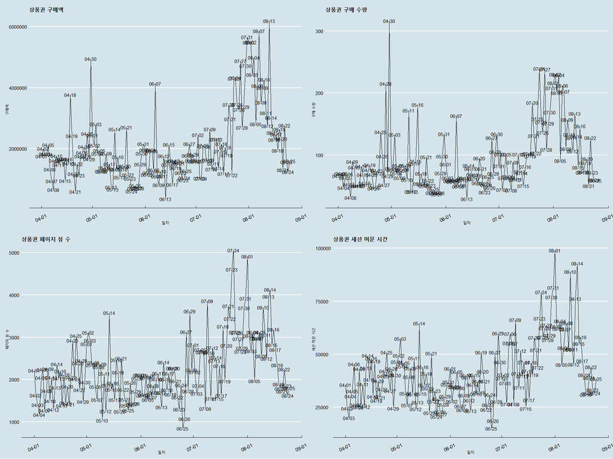

```r
ggarrange(C10_AM, C10_CT, C10_PAG, C10_HR)
```

#### 7월의 어떠한 이벤트 행사가 있었는지 확인할 필요가 있고 4월 30일의 구매됐던 내역 또한 살펴볼 필요성이 있음

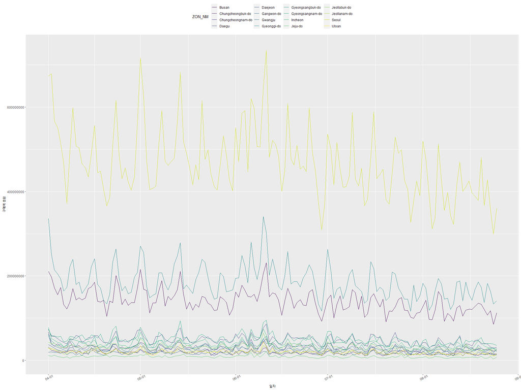

#### Insight : 지역별 총 구매액을 지역별로 뽑아본 결과, 서울의 치중된 그래프의 모습을 볼 수 있지만,

#### 이는 서울에 인구가 몰린 탓에 생긴 그래프로 추측이 된다

## 지역별 총구매액을 지역별 평균액으로 ↓

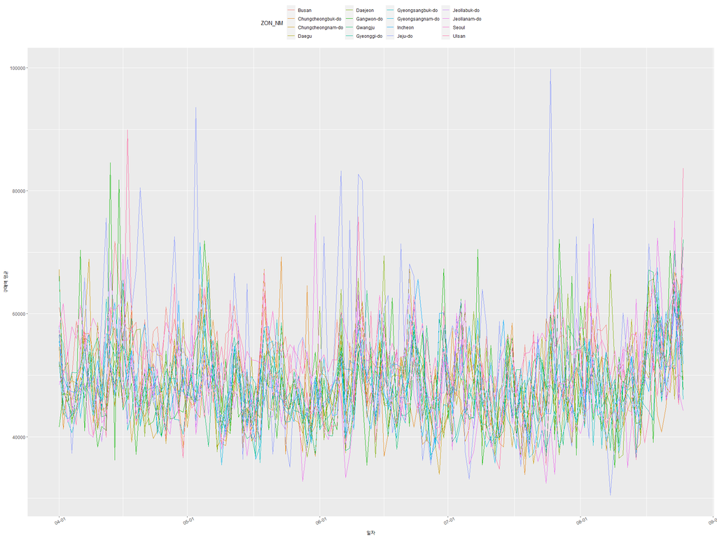

#### Insight : 구매액을 평균을 내보았더니 구매액의 쏠림은 없어 보이고 전체적으로 비슷한 구매액 추세

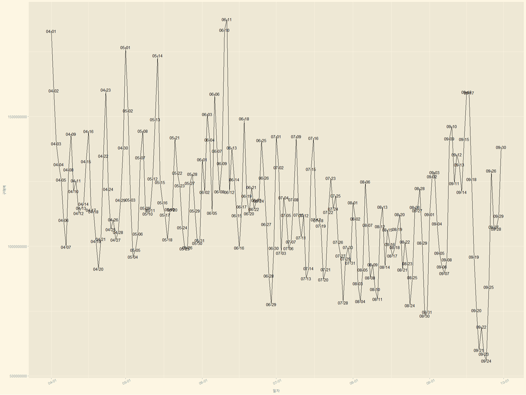

```r
ggarrange(ALL_AM)
```

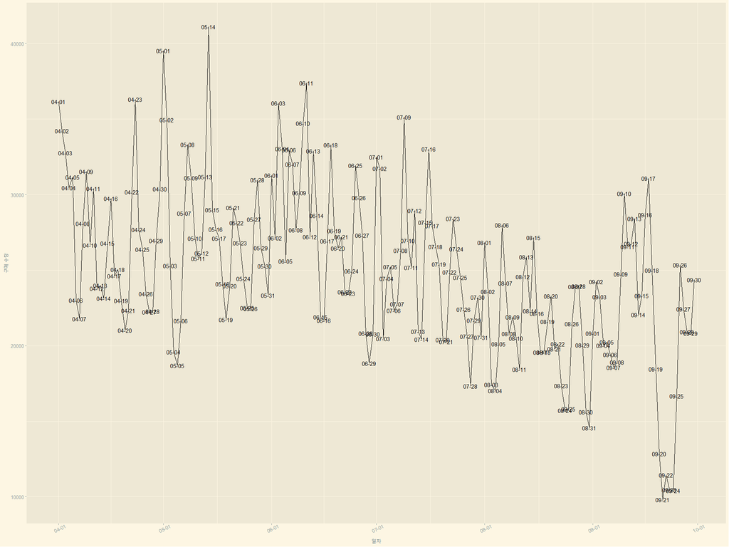

```r
ggarrange(ALL_CT)
```

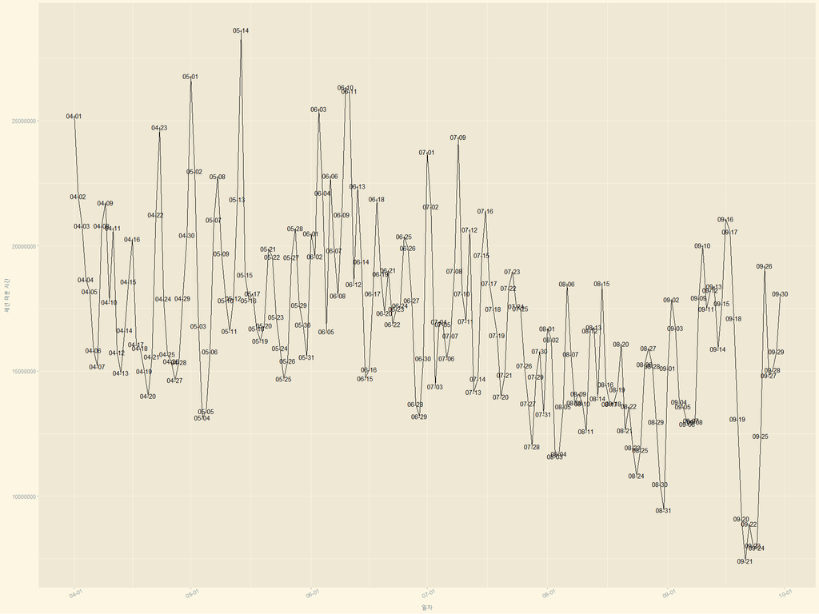

```r
ggarrange(ALL_HR)
```

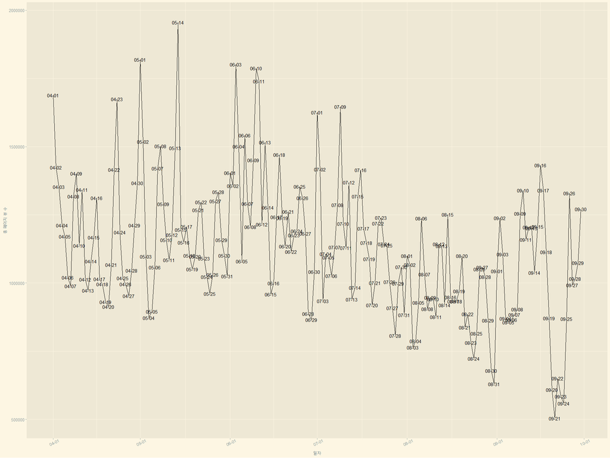

```r
ggarrange(ALL_PAG)
```

#### 총 구매액, 구매수량, 페이지 뷰 수, 세션 머문 시간의 추세를 보니 패션의 4가지 추세와 매우 흡사한 파형을 보임, 패션을 제외한 상품군들의 4가지 추세 파악의 필요성을 느낌

```r
no_fashion$CN_our <- as.character(no_fashion$CN_our)


no_fashion_sum <- no_fashion %>%
  group_by(SESS_DT) %>%
  summarise(PD_BUY_CT = sum(PD_BUY_CT),
            PD_BUY_AM = sum(PD_BUY_AM),
            TOT_PAG_VIEW_CT = sum(TOT_PAG_VIEW_CT),
            TOT_SESS_HR_V = sum(TOT_SESS_HR_V)
            ) %>%
  arrange(SESS_DT)

no_fashion_sum$DT_CHR <- as.character(no_fashion_sum$SESS_DT, format = '%m-%d')
```

```r
NO_FASH_ALL_AM <- ggplot(no_fashion_sum, aes(x = SESS_DT, y = PD_BUY_AM)) +
  geom_line() + labs(x = '일자', y = '총 구매액') +
  scale_x_date(date_breaks = 'month', labels = date_format('%m-%d')) +
  scale_color_viridis(discrete = TRUE) + theme_solarized_2() +
  annotate('text', x = no_fashion_sum$SESS_DT, y = no_fashion_sum$PD_BUY_AM, label = no_fashion_sum$DT_CHR) +
  theme(axis.text.x = element_text(angle = 25), legend.position = 'bottom')
```

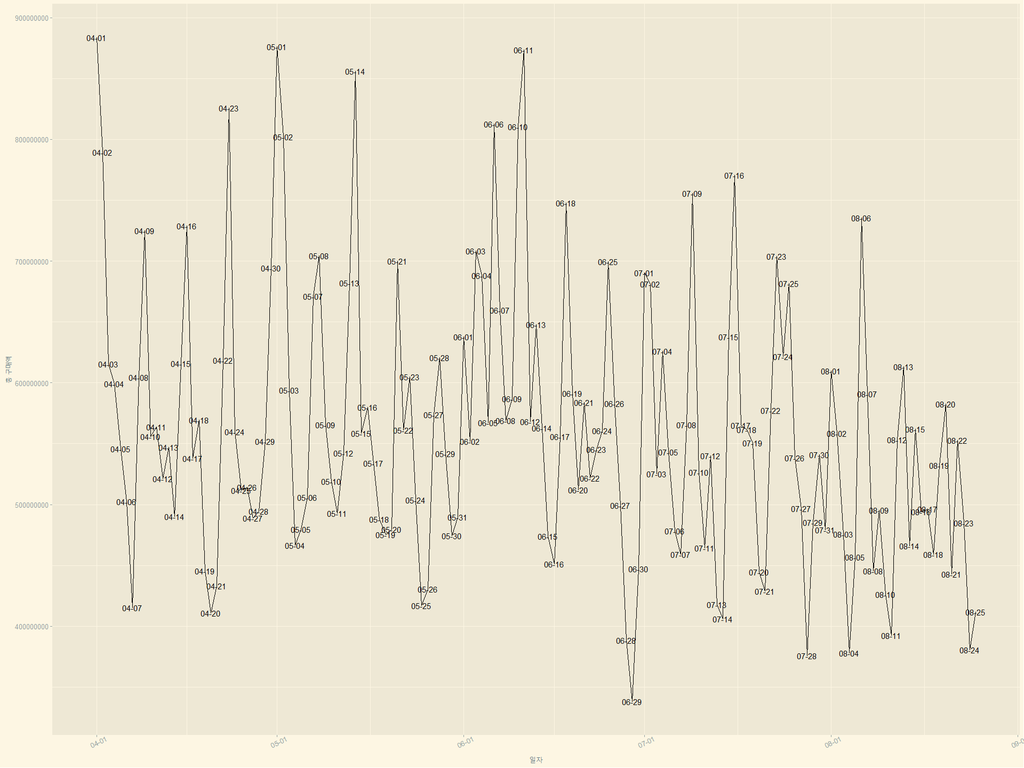

```r
ggarrange(NO_FASH_ALL_AM)
```

```r
NO_FASH_ALL_CT <- ggplot(no_fashion_sum, aes(x = SESS_DT, y = PD_BUY_CT)) +
  geom_line() + labs(x = '일자', y = '총 구매 수량') +
  scale_x_date(date_breaks = 'month', labels = date_format('%m-%d')) +
  scale_color_viridis(discrete = TRUE) + theme_solarized_2() +
  annotate('text', x = no_fashion_sum$SESS_DT, y = no_fashion_sum$PD_BUY_CT, label = no_fashion_sum$DT_CHR) +
  theme(axis.text.x = element_text(angle = 25), legend.position = 'bottom')
```

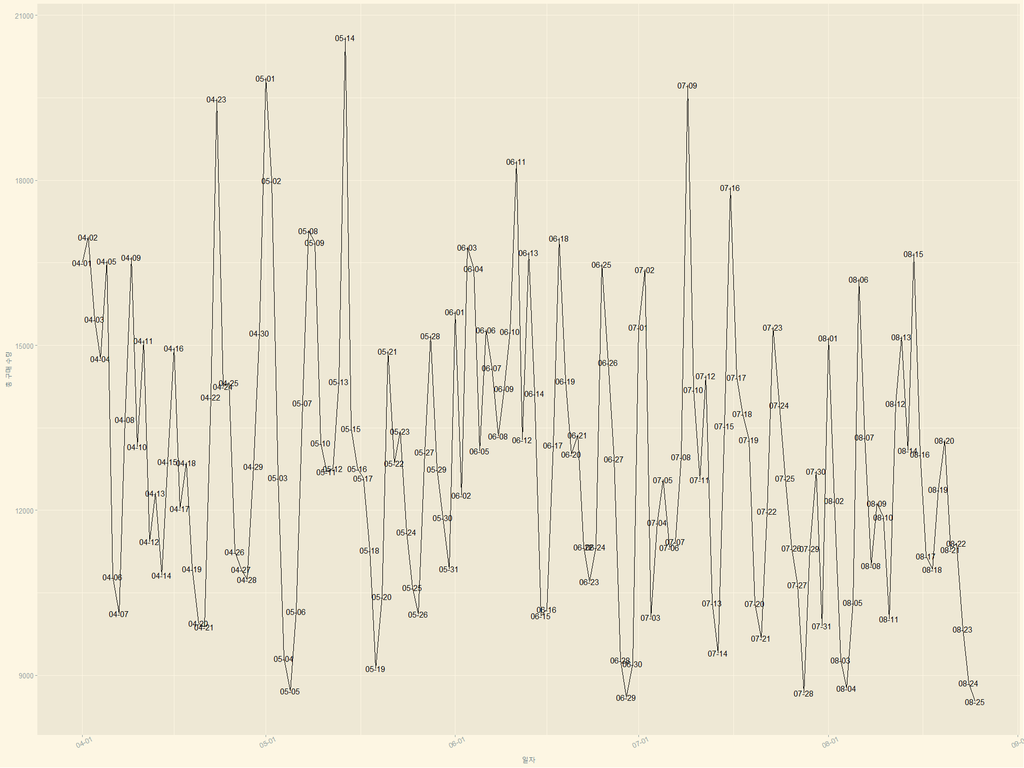

```r
ggarrange(NO_FASH_ALL_CT)
```

```r
NO_FASH_ALL_PAG <- ggplot(no_fashion_sum, aes(x = SESS_DT, y = TOT_PAG_VIEW_CT)) +
  geom_line() + labs(x = '일자', y = '총 페이지뷰 수') +
  scale_x_date(date_breaks = 'month', labels = date_format('%m-%d')) +
  scale_color_viridis(discrete = TRUE) + theme_solarized_2() +
  annotate('text', x = no_fashion_sum$SESS_DT, y = no_fashion_sum$TOT_PAG_VIEW_CT, label = no_fashion_sum$DT_CHR) +
  theme(axis.text.x = element_text(angle = 25), legend.position = 'bottom')
```

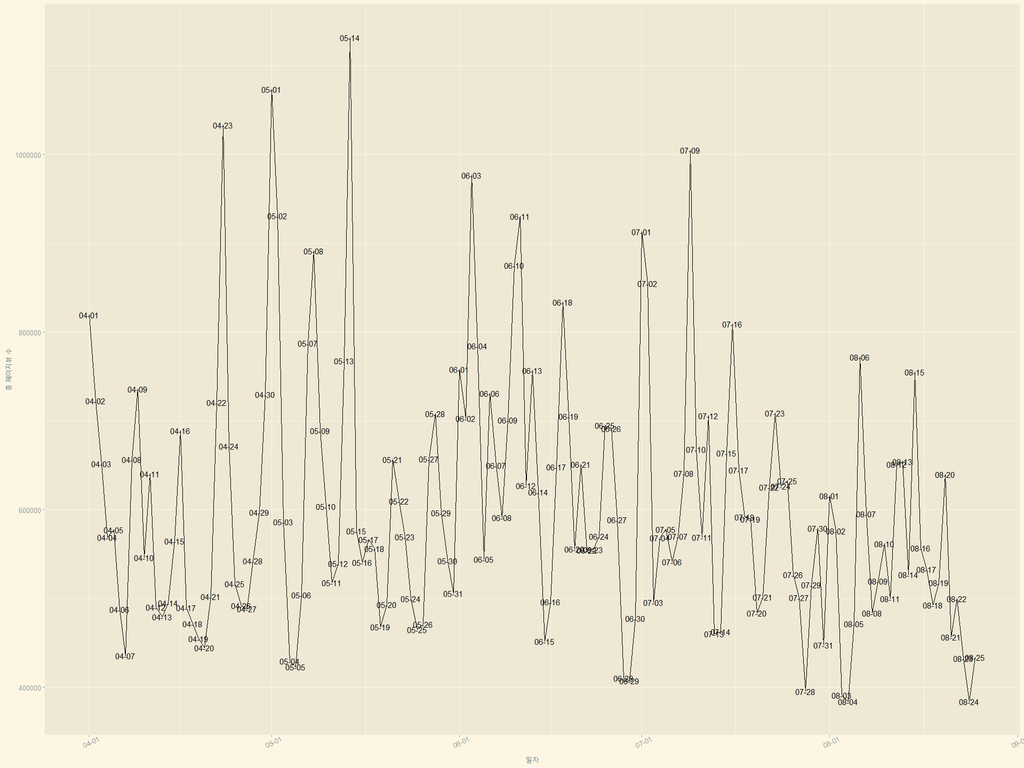

```r
ggarrange(NO_FASH_ALL_PAG)
```

```r
NO_FASH_ALL_HR <- ggplot(no_fashion_sum, aes(x = SESS_DT, y = TOT_SESS_HR_V)) +
  geom_line() + labs(x = '일자', y = '총 세션 머문 시간') +
  scale_x_date(date_breaks = 'month', labels = date_format('%m-%d')) +
  scale_color_viridis(discrete = TRUE) + theme_solarized_2() +
  annotate('text', x = no_fashion_sum$SESS_DT, y = no_fashion_sum$TOT_SESS_HR_V, label = no_fashion_sum$DT_CHR) +
  theme(axis.text.x = element_text(angle = 25), legend.position = 'bottom')
```

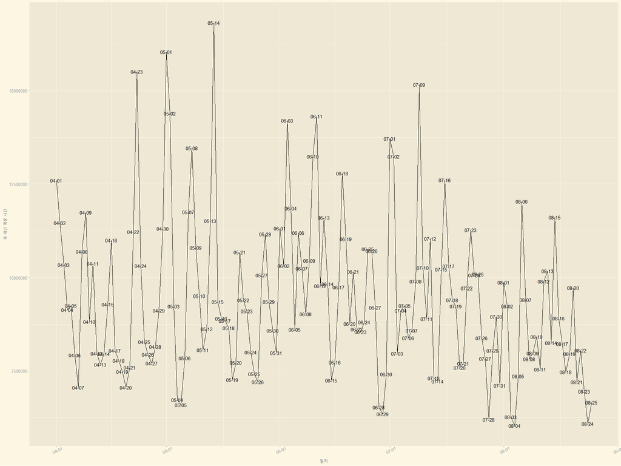

```r
ggarrange(NO_FASH_ALL_HR)
```

## 패션제외한 구매패턴은 다른 것을 볼 수 있음

## 검색건수 및 검색어에 관한 기초 데이터 탐색

```r
new_search2$SESS_DT <- as.character(new_search2$SESS_DT)
new_search2$SESS_DT <- as.Date(new_search2$SESS_DT, tryFormats = c('%Y%m%d', '%Y-%m-%d'))

new_search2_need <- new_search2[-2]

new_search2_need$SEARCH_CNT <- ifelse(is.na(new_search2_need$SEARCH_CNT), 0, new_search2_need$SEARCH_CNT)
new_search2_sum <- new_search2_need %>%
  group_by(SESS_DT, DAY_OF_WEEK) %>%
  summarise(SEARCH_CNT = sum(SEARCH_CNT))


join_all$SESS_DT <- as.Date(join_all$SESS_DT)
new_search2_sum$SESS_DT <- as.Date(new_search2_sum$SESS_DT)


join_search <- inner_join(join_all, new_search2_sum, by = 'SESS_DT')

search2_need <- join_search[, -c(1,2,4,5,6)]
search2_need$DT_CHR <- as.character(search2_need$SESS_DT, format = '%m-%d')

GG_SEARCH <- ggplot(search2_need, aes(x = SESS_DT, y = SEARCH_CNT)) +
  geom_line() + labs(x = '일자',  y = '검색 건수', title = "일자별 검색 건수") +
  annotate("text", x = search2_need$SESS_DT, y = search2_need$SEARCH_CNT, label = search2_need$DT_CHR) +
  scale_x_date(date_breaks = 'month',
               labels = date_format('%m-%d')) +
  scale_color_economist() + theme_economist() +
  theme(axis.text.x = element_text(angle =25), legend.position = 'none')
```

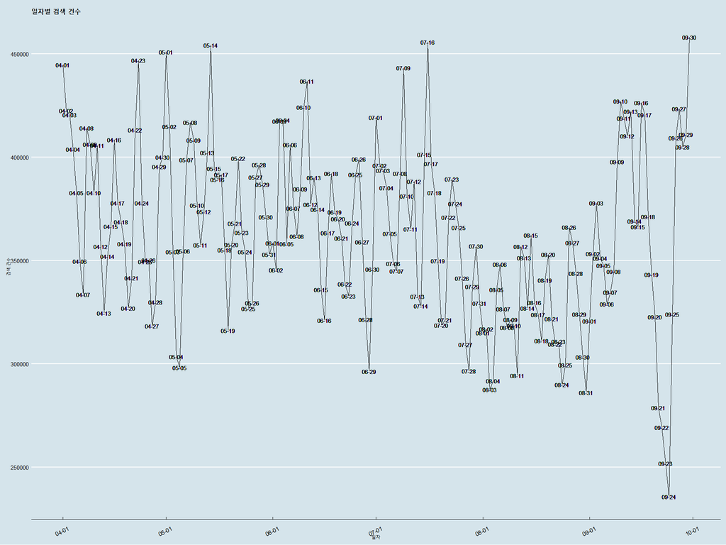

```r
ggarrange(GG_SEARCH)
```

#### 검색어 워드클라우드 생성

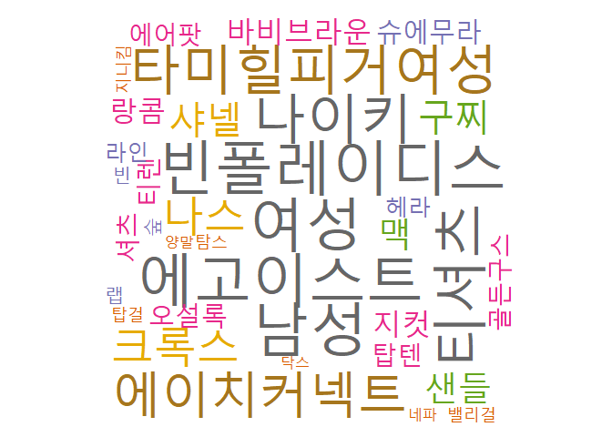

```r
new_search2$SESS_DT <- as.character(new_search2$SESS_DT)
new_search2$SESS_DT <- as.Date(new_search2$SESS_DT, tryFormats = c('%Y%m%d', '%Y-%m-%d'))

kwddt <- new_search2 %>%
    group_by(KWD_NM) %>%
    summarise(TOTCNT = sum(SEARCH_CNT, na.rm = T)) %>%
    arrange(desc(TOTCNT))


pal <- brewer.pal(8, 'Dark2')

set.seed(14)

wordcloud(words = kwddt$KWD_NM,
          freq = kwddt$TOTCNT,
          min.freq = 50,
          max.words = 300,
          random.order = F,
          rot.per = .1,
          scale = c(5, 0.5),
          colors = pal)
```

```r
kw_adi <- new_search2 %>%
  filter(KWD_NM == '아디다스') %>%
  select('SESS_DT', 'SEARCH_CNT') %>%
  rename(adidas = SEARCH_CNT)  %>%
  group_by(SESS_DT) %>%
  summarise(adi_cnt = sum(adidas)) %>%
  arrange(SESS_DT)

kw_adi$week <- cut(kw_adi$SESS_DT, breaks = "week", start.on.monday = F)

kw_adi <- dcast(kw_adi, week ~ . , value.var = "adi_cnt",
                fun.aggregate = function(x) sum(x, na.rm=T))
kw_adi <- kw_adi %>%
  rename(아디다스 = ".")

# ----------
kw_gior <- new_search2 %>%
  filter(KWD_NM == '지오다노') %>%
  select('SESS_DT', 'SEARCH_CNT') %>%
  rename(giordano = SEARCH_CNT) %>%
  group_by(SESS_DT) %>%
  summarise(gio_cnt = sum(giordano)) %>%
  arrange(SESS_DT)

kw_gior$week <- cut(kw_gior$SESS_DT, breaks = "week", start.on.monday = F)

kw_gior <- dcast(kw_gior, week ~ . , value.var = "gio_cnt",
                 fun.aggregate = function(x) sum(x, na.rm=T))
kw_gior <- kw_gior %>%
  rename(지오다노 = ".")

# ----------
kw_pla <- new_search2 %>%
  filter(KWD_NM == '플라스틱아일랜드') %>%
  select('SESS_DT', 'SEARCH_CNT') %>%
  rename(plasticisland = SEARCH_CNT) %>%
  group_by(SESS_DT) %>%
  summarise(pla_cnt = sum(plasticisland)) %>%
  arrange(SESS_DT)

kw_pla$week <- cut(kw_pla$SESS_DT, breaks = "week", start.on.monday = F)

kw_pla <- dcast(kw_pla, week ~ . , value.var = "pla_cnt",
                fun.aggregate = function(x) sum(x, na.rm=T))
kw_pla <- kw_pla %>%
  rename(플라스틱아일랜드 = ".")


# ----------
kw_oli <- new_search2 %>%
  filter(KWD_NM == '올리브데올리브') %>%
  select('SESS_DT', 'SEARCH_CNT') %>%
  rename(olive = SEARCH_CNT) %>%
  group_by(SESS_DT) %>%
  summarise(oli_cnt = sum(olive)) %>%
  arrange(SESS_DT)

kw_oli$week <- cut(kw_oli$SESS_DT, breaks = "week", start.on.monday = F)

kw_oli <- dcast(kw_oli, week ~ . , value.var = "oli_cnt",
                fun.aggregate = function(x) sum(x, na.rm=T))
kw_oli <- kw_oli %>%
  rename(올리브데올리브 = ".")


# ----------
kw_laco <- new_search2 %>%
  filter(KWD_NM == '라코스테') %>%
  select('SESS_DT', 'SEARCH_CNT') %>%
  rename(lacoste = SEARCH_CNT) %>%
  group_by(SESS_DT) %>%
  summarise(laco_cnt = sum(lacoste)) %>%
  arrange(SESS_DT)

kw_laco$week <- cut(kw_laco$SESS_DT, breaks = "week", start.on.monday = F)

kw_laco <- dcast(kw_laco, week ~ . , value.var = "laco_cnt",
                 fun.aggregate = function(x) sum(x, na.rm=T))
kw_laco <- kw_laco %>%
  rename(라코스테 = ".")


# ----------
kw_ysl <- new_search2 %>%
  filter(KWD_NM == '입생로랑') %>%
  select('SESS_DT', 'SEARCH_CNT') %>%
  rename(ysl = SEARCH_CNT) %>%
  group_by(SESS_DT) %>%
  summarise(ysl_cnt = sum(ysl)) %>%
  arrange(SESS_DT)

kw_ysl$week <- cut(kw_ysl$SESS_DT, breaks = "week", start.on.monday = F)

kw_ysl <- dcast(kw_ysl, week ~ . , value.var = "ysl_cnt",
                fun.aggregate = function(x) sum(x, na.rm=T))
kw_ysl <- kw_ysl %>%
  rename(입생로랑 = ".")

# ----------
kw_gu <- new_search2 %>%
  filter(KWD_NM == '구찌') %>%
  select('SESS_DT', 'SEARCH_CNT') %>%
  rename(gucci = SEARCH_CNT) %>%
  group_by(SESS_DT) %>%
  summarise(guc_cnt = sum(gucci)) %>%
  arrange(SESS_DT)

kw_gu$week <- cut(kw_gu$SESS_DT, breaks = "week", start.on.monday = F)

kw_gu <- dcast(kw_gu, week ~ . , value.var = "guc_cnt",
               fun.aggregate = function(x) sum(x, na.rm=T))
kw_gu <- kw_gu %>%
  rename(구찌 = ".")

# ----------
kw_ono <- new_search2 %>%
  filter(KWD_NM == '온앤온') %>%
  select('SESS_DT', 'SEARCH_CNT') %>%
  rename(onandon = SEARCH_CNT) %>%
  group_by(SESS_DT) %>%
  summarise(on_cnt = sum(onandon)) %>%
  arrange(SESS_DT)

kw_ono$week <- cut(kw_ono$SESS_DT, breaks = "week", start.on.monday = F)

kw_ono <- dcast(kw_ono, week ~ . , value.var = "on_cnt",
                fun.aggregate = function(x) sum(x, na.rm=T))
kw_ono <- kw_ono %>%
  rename(온앤온 = ".")

# ----------
kw_eco <- new_search2 %>%
  filter(KWD_NM == '에코백') %>%
  select('SESS_DT', 'SEARCH_CNT') %>%
  rename(ecobag = SEARCH_CNT) %>%
  group_by(SESS_DT) %>%
  summarise(eco_cnt = sum(ecobag)) %>%
  arrange(SESS_DT)

kw_eco$week <- cut(kw_eco$SESS_DT, breaks = "week", start.on.monday = F)

kw_eco <- dcast(kw_eco, week ~ . , value.var = "eco_cnt",
                fun.aggregate = function(x) sum(x, na.rm=T))
kw_eco <- kw_eco %>%
  rename(에코백 = ".")

# ----------
kw_nan <- new_search2 %>%
  filter(KWD_NM == '난닝구') %>%
  select('SESS_DT', 'SEARCH_CNT') %>%
  rename(nanninggu = SEARCH_CNT) %>%
  group_by(SESS_DT) %>%
  summarise(nan_cnt = sum(nanninggu)) %>%
  arrange(SESS_DT)

kw_nan$week <- cut(kw_nan$SESS_DT, breaks = "week", start.on.monday = F)

kw_nan <- dcast(kw_nan, week ~ . , value.var = "nan_cnt",
                fun.aggregate = function(x) sum(x, na.rm=T))
kw_nan <- kw_nan %>%
  rename(난닝구 = ".")
```

```r
kw_top <- inner_join(kw_adi, kw_gior, by="week")
kw_top <- inner_join(kw_top, kw_pla, by="week")
kw_top <- inner_join(kw_top, kw_oli, by="week")
kw_top <- inner_join(kw_top, kw_laco, by="week")
kw_top <- inner_join(kw_top, kw_ysl, by="week")
kw_top <- inner_join(kw_top, kw_gu, by="week")
kw_top <- inner_join(kw_top, kw_ono, by="week")
kw_top <- inner_join(kw_top, kw_eco, by="week")
kw_top <- inner_join(kw_top, kw_nan, by="week")

long_kwtop10 <- kw_top %>%
  gather(key = "검색어", value = "검색건수", -week)
```

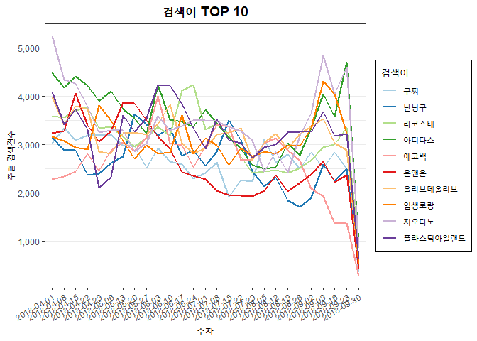

```r
ggplot(long_kwtop10, aes(x=week, y=검색건수, group=검색어)) +
  geom_line(aes(color = 검색어), size=1) +
  scale_color_manual(values = brewer.pal(12,'Paired')) +
  # theme_minimal() +
  ggtitle("검색어 TOP 10") +
  labs(x = "주차", y = "주별 검색건수") +
  theme_bw() +
  theme(plot.title = element_text(hjust = 0.5,
                                  size = 14,
                                  color="Black",
                                  face = 'bold')) +
  theme(panel.grid.major.x = element_blank(),
        panel.grid.minor.x = element_blank()) +
  theme(axis.text.x=element_text(angle=30, hjust=1)) +
  theme(legend.box.background =
          element_rect(fill = "Black"),
        legend.box.margin = margin(.5, .5, .5, .5)) +
  theme(legend.text = element_text( size = 8)) +
  theme(legend.title = element_text(size = 12)) +
  scale_y_continuous(labels = scales::comma)
```